# Single Cell Analysis with Seurat

Pragati Upadhyay

2023-03-26

To study cell to cell variation within a population, we perform single cell analysis. Single-cell analysis is of critical importance in revealing population heterogeneity, identifying minority sub-populations of interest, as well as discovering unique characteristics of individual cells.

I will be following the tutorial from Satija Lab which can be found [here](https://satijalab.org/seurat/articles/pbmc3k_tutorial.html)

```r
#Loading the required libraries
library(dplyr)
library(Seurat)
library(patchwork)
```

The dataset is of Peripheral Blood Mononuclear Cells (PBMC) from 10X Genomics. It has 2,700 single cells that were sequenced on the Illumina NextSeq 500.

**Setup the Seurat Object**

```r
# Load the PBMC dataset
pbmc.data <- Read10X(data.dir ="filtered_gene_bc_matrices/hg19/")

# Initialize the Seurat object with the raw (non-normalized data).
pbmc <- CreateSeuratObject(counts = pbmc.data, project = "pbmc3k", min.cells = 3, min.features = 200)
pbmc
```

```
## An object of class Seurat
## 13714 features across 2700 samples within 1 assay
## Active assay: RNA (13714 features, 0 variable features)
```

Now this pbmc variable is our Seurat object. It has 13714 features across 2700 samples.

**Standard pre-processing workflow**

These represent the selection and filtration of cells based on QC metrics, data normalization and scaling, and the detection of highly variable features.

There might be a chance that during sequencing, cells die thus we can get a lot of contamination in the form of mitochondrial genes, so to remove them and to remove low quality cells the Quality Control is performed.

**QC and selecting cells for further analysis**

```r
# The [[ operator can add columns to object metadata. This is a great place to stash QC stats
pbmc[["percent.mt"]] <- PercentageFeatureSet(pbmc, pattern = "^MT-")

# Show QC metrics for the first 5 cells
head(pbmc@meta.data, 5)
```

```
##                  orig.ident nCount_RNA nFeature_RNA percent.mt
## AAACATACAACCAC-1     pbmc3k       2419          779  3.0177759
## AAACATTGAGCTAC-1     pbmc3k       4903         1352  3.7935958
## AAACATTGATCAGC-1     pbmc3k       3147         1129  0.8897363
## AAACCGTGCTTCCG-1     pbmc3k       2639          960  1.7430845
## AAACCGTGTATGCG-1     pbmc3k        980          521  1.2244898
```

The column percent.mt shows us the % of mitochondrial genes, nCount_RNA is the total number of molecules detected within a cell, and nFeature_RNA is the number of genes detected in each cell. Low nFeature_RNA for a cell indicates that it may be dead/dying or an empty droplet. High nCount_RNA and/or nFeature_RNA indicates that the “cell” may in fact be a doublet.

**Visualize QC data matrices**

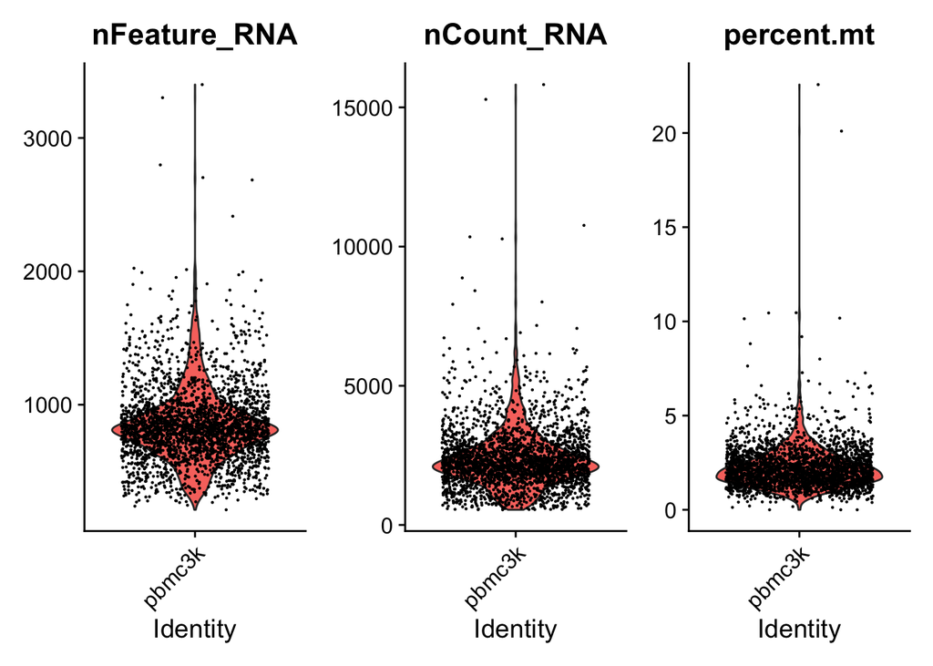

```r
# Visualize QC metrics as a violin plot
VlnPlot(pbmc, features = c("nFeature_RNA", "nCount_RNA", "percent.mt"), ncol = 3)
```

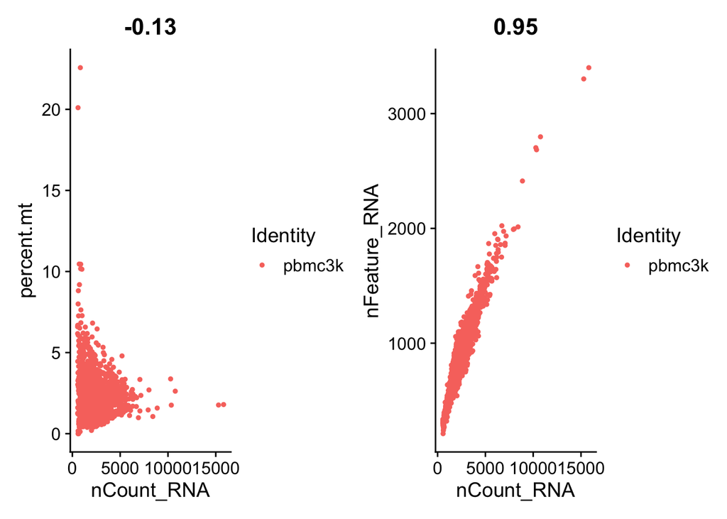

```r
# FeatureScatter is typically used to visualize feature-feature relationships, but can be used
# for anything calculated by the object, i.e. columns in object metadata, PC scores etc.

plot1 <- FeatureScatter(pbmc, feature1 = "nCount_RNA", feature2 = "percent.mt")
plot2 <- FeatureScatter(pbmc, feature1 = "nCount_RNA", feature2 = "nFeature_RNA")

plot1 + plot2
```

**Subset the data**

```r
pbmc1 <- subset(pbmc, subset = nFeature_RNA > 200 & nFeature_RNA < 2500 & percent.mt < 5)
```

**Normalizing the data**

After removing unwanted cells from the dataset, the next step is to normalize the data.

```r
pbmc2 <- NormalizeData(pbmc1, normalization.method = "LogNormalize", scale.factor = 10000)
```

**Identification of highly variable features (feature selection)**

To find the genes that are highly expressed, we use the function `FindVariableFeatures()`. These cells exhibit high cell-to-cell variation in the dataset, identifying them will help in downstream analysis.

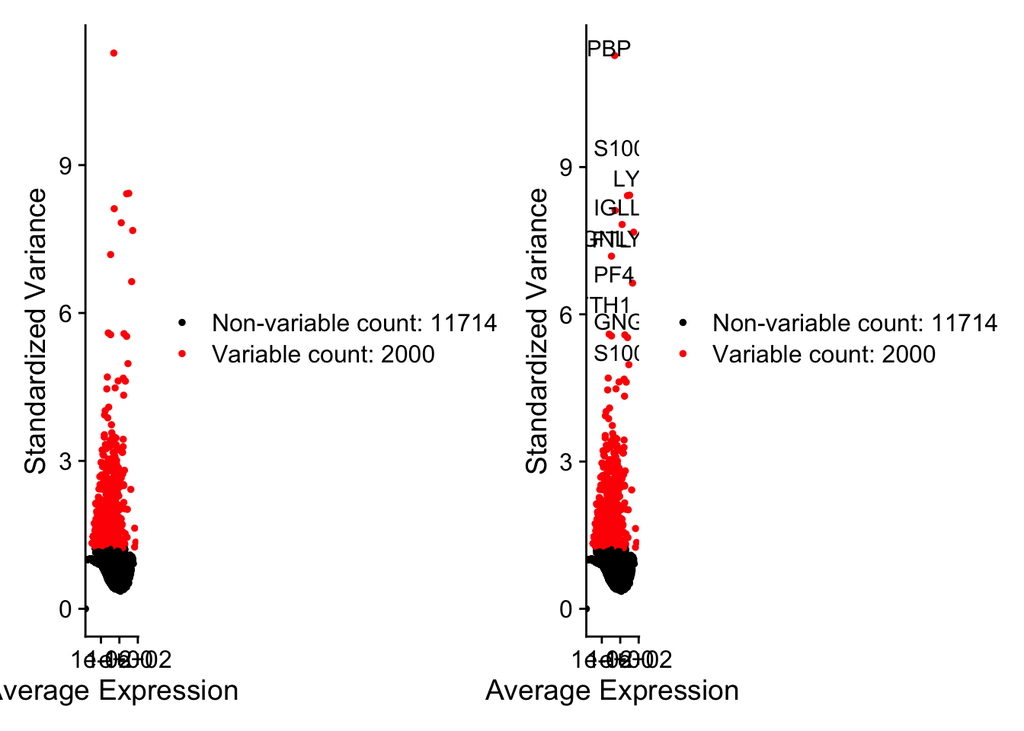

```r
pbmc3 <- FindVariableFeatures(pbmc2, selection.method = "vst", nfeatures = 2000)

# Identify the 10 most highly variable genes
top10 <- head(VariableFeatures(pbmc3), 10)

# plot variable features with labels
plot1 <- VariableFeaturePlot(pbmc3)

# plot variable features without labels
plot2 <- LabelPoints(plot = plot1, points = top10, repel = TRUE)

# Combining the plots
plot1 + plot2
```

```r
x <- VariableFeatures(pbmc3)
head(x)
```

```
## [1] "PPBP"   "LYZ"    "S100A9" "IGLL5"  "GNLY"   "FTL"
```

There are 2000 variable features in this dataset

**Scaling the data**

To give equal weight to our data points, we perform scaling. The function `ScaleData()` is used to perform scaling.

```r
all.genes <- rownames(pbmc3)
pbmc4 <- ScaleData(pbmc3, features = all.genes)
```

**Perform linear dimensional reduction**

To reduce the dimensionality of this complex data, we perform PCA.

```r
pbmc5 <- RunPCA(pbmc4, features = VariableFeatures(object = pbmc4))

# Examine and visualize PCA results a few different ways
print(pbmc5[["pca"]], dims = 1:5, nfeatures = 5)
```

```
## PC_ 1
## Positive:  CST3, TYROBP, LST1, AIF1, FTL
## Negative:  MALAT1, LTB, IL32, IL7R, CD2
## PC_ 2
## Positive:  CD79A, MS4A1, TCL1A, HLA-DQA1, HLA-DQB1
## Negative:  NKG7, PRF1, CST7, GZMB, GZMA
## PC_ 3
## Positive:  HLA-DQA1, CD79A, CD79B, HLA-DQB1, HLA-DPB1
## Negative:  PPBP, PF4, SDPR, SPARC, GNG11
## PC_ 4
## Positive:  HLA-DQA1, CD79B, CD79A, MS4A1, HLA-DQB1
## Negative:  VIM, IL7R, S100A6, IL32, S100A8
## PC_ 5
## Positive:  GZMB, NKG7, S100A8, FGFBP2, GNLY
## Negative:  LTB, IL7R, CKB, VIM, MS4A7
```

Visualizing the components with different graphs

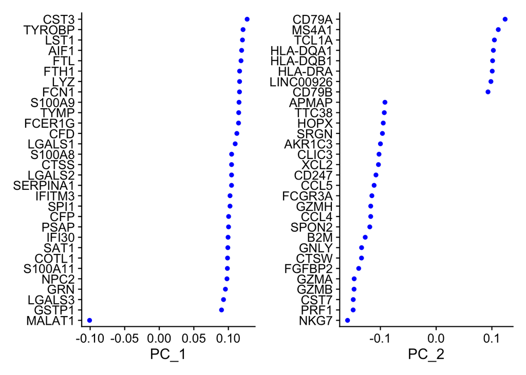

```r
VizDimLoadings(pbmc5, dims = 1:2, reduction = "pca")
```

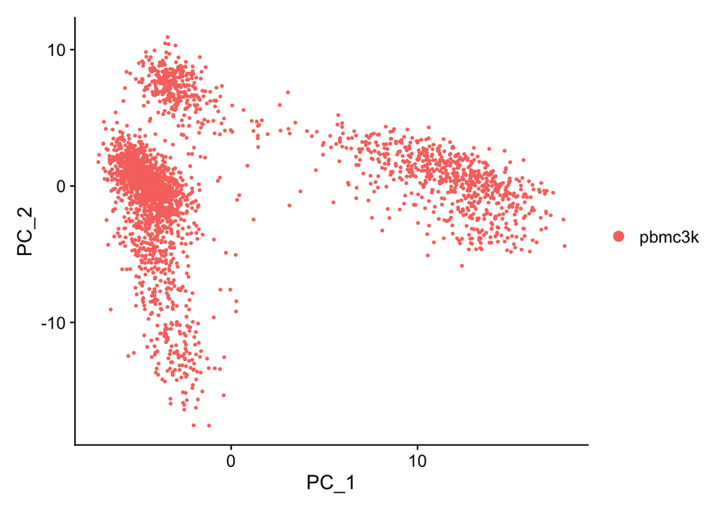

```r
DimPlot(pbmc5, reduction = "pca")
```

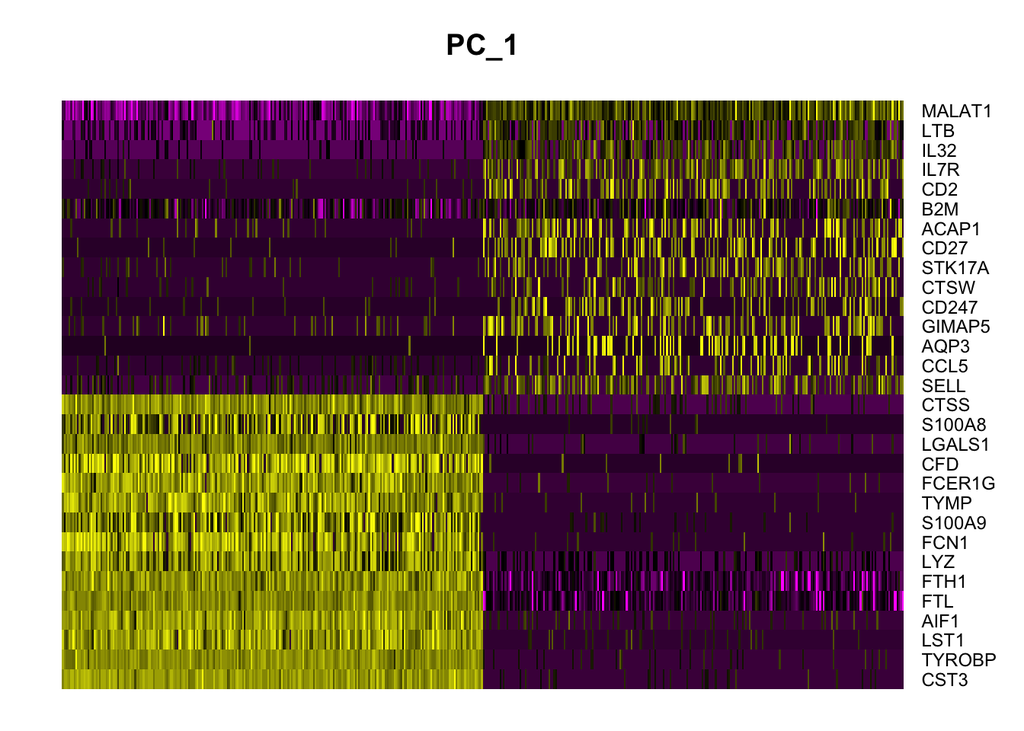

```r
DimHeatmap(pbmc5, dims = 1, cells = 500, balanced = TRUE)
```

Generating an elbow plot to determine how many PCs we should consider

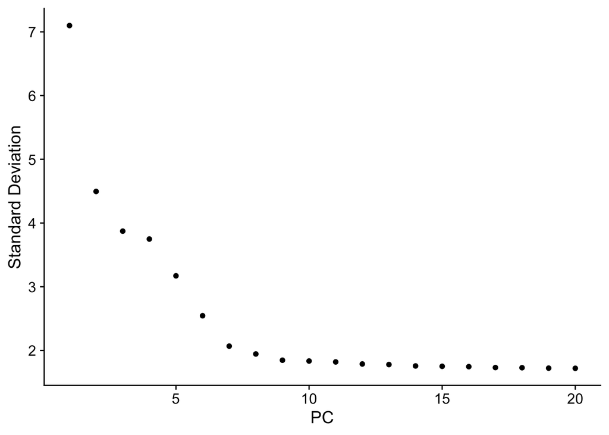

```r
ElbowPlot(pbmc5)
```

We can observe an ‘elbow’ around PC9-10, suggesting that the majority of true signal is captured in the first 10 PCs.

**Cluster the cells**

We are finding the nearest neighbors with `FindNeighbors()` function and to find the clusters of the cells that can be grouped together, `FindClusters()` function is used.

```r
pbmc6 <- FindNeighbors(pbmc5, dims = 1:10)
pbmc7 <- FindClusters(pbmc6, resolution = 0.5)
```

```
## Modularity Optimizer version 1.3.0 by Ludo Waltman and Nees Jan van Eck
##
## Number of nodes: 2638
## Number of edges: 95965
##
## Running Louvain algorithm...
## Maximum modularity in 10 random starts: 0.8723
## Number of communities: 9
## Elapsed time: 0 seconds
```

```r
head(Idents(pbmc7), 5)
```

```
## AAACATACAACCAC-1 AAACATTGAGCTAC-1 AAACATTGATCAGC-1 AAACCGTGCTTCCG-1
##                2                3                2                1
## AAACCGTGTATGCG-1
##                6
## Levels: 0 1 2 3 4 5 6 7 8
```

**Run non-linear dimensional reduction (UMAP/tSNE)**

Placing the similar cells together in a low dimensional space with UMAP

```r
pbmc8 <- RunUMAP(pbmc7, dims = 1:10)
```

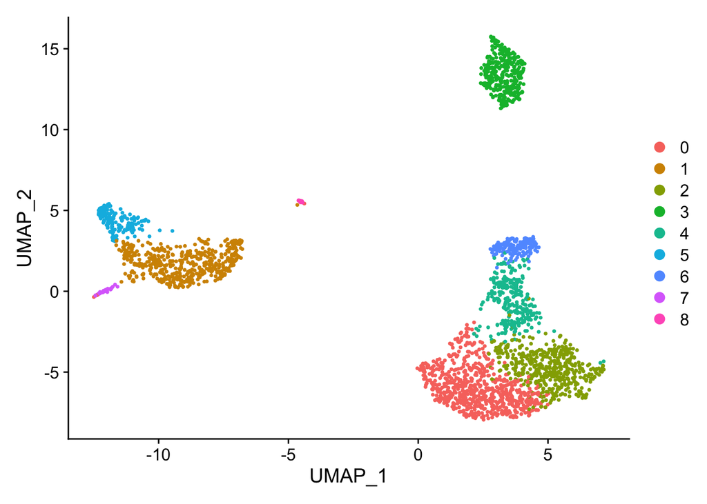

```r
DimPlot(pbmc8, reduction = "umap")
```

**Finding differentially expressed features (cluster biomarkers)**

Next step is to find the Biomarkers that will help us in the identification of cell type. This is accomplished with `FindMarkers()`.

```r
# find all markers of cluster 2
cluster2.markers <- FindMarkers(pbmc8, ident.1 = 2, min.pct = 0.25)
head(cluster2.markers, n = 5)
```

```
##             p_val avg_log2FC pct.1 pct.2    p_val_adj
## IL32 2.593535e-91  1.2154360 0.949 0.466 3.556774e-87
## LTB  7.994465e-87  1.2828597 0.981 0.644 1.096361e-82
## CD3D 3.922451e-70  0.9359210 0.922 0.433 5.379250e-66
## IL7R 1.130870e-66  1.1776027 0.748 0.327 1.550876e-62
## LDHB 4.082189e-65  0.8837324 0.953 0.614 5.598314e-61
```

We can see the first 5 markers of cluster type 2 here.

```r
# find all markers distinguishing cluster 5 from clusters 0 and 3
cluster5.markers <- FindMarkers(pbmc8, ident.1 = 5, ident.2 = c(0, 3), min.pct = 0.25)
head(cluster5.markers, n = 5)
```

```
##                       p_val avg_log2FC pct.1 pct.2     p_val_adj
## FCGR3A        2.150929e-209   4.267579 0.975 0.039 2.949784e-205
## IFITM3        6.103366e-199   3.877105 0.975 0.048 8.370156e-195
## CFD           8.891428e-198   3.411039 0.938 0.037 1.219370e-193
## CD68          2.374425e-194   3.014535 0.926 0.035 3.256286e-190
## RP11-290F20.3 9.308287e-191   2.722684 0.840 0.016 1.276538e-186
```

Here we can see 5 markers that can help us to distinguish cluster 5 from cluster 0 and 3.

Now we will find the markers for each of the clusters

```r
# find markers for every cluster compared to all remaining cells, report only the positive
# ones
pbmc.markers <- FindAllMarkers(pbmc8, only.pos = TRUE, min.pct = 0.25, logfc.threshold = 0.25)
pbmc.markers %>%
    group_by(cluster) %>%
    slice_max(n = 2, order_by = avg_log2FC)
```

```
## # A tibble: 18 × 7
## # Groups:   cluster [9]
##        p_val avg_log2FC pct.1 pct.2 p_val_adj cluster gene
##        <dbl>      <dbl> <dbl> <dbl>     <dbl> <fct>   <chr>
##  1 1.17e- 83       1.33 0.435 0.108 1.60e- 79 0       CCR7
##  2 1.74e-109       1.07 0.897 0.593 2.39e-105 0       LDHB
##  3 0               5.57 0.996 0.215 0         1       S100A9
##  4 0               5.48 0.975 0.121 0         1       S100A8
##  5 7.99e- 87       1.28 0.981 0.644 1.10e- 82 2       LTB
##  6 2.61e- 59       1.24 0.424 0.111 3.58e- 55 2       AQP3
##  7 0               4.31 0.936 0.041 0         3       CD79A
##  8 9.48e-271       3.59 0.622 0.022 1.30e-266 3       TCL1A
##  9 4.93e-169       3.01 0.595 0.056 6.76e-165 4       GZMK
## 10 1.17e-178       2.97 0.957 0.241 1.60e-174 4       CCL5
## 11 3.51e-184       3.31 0.975 0.134 4.82e-180 5       FCGR3A
## 12 2.03e-125       3.09 1     0.315 2.78e-121 5       LST1
## 13 6.82e-175       4.92 0.958 0.135 9.36e-171 6       GNLY
## 14 1.05e-265       4.89 0.986 0.071 1.44e-261 6       GZMB
## 15 1.48e-220       3.87 0.812 0.011 2.03e-216 7       FCER1A
## 16 1.67e- 21       2.87 1     0.513 2.28e- 17 7       HLA-DPB1
## 17 3.68e-110       8.58 1     0.024 5.05e-106 8       PPBP
## 18 7.73e-200       7.24 1     0.01  1.06e-195 8       PF4
```

We can see the 2 biomarkers for each of the clusters here. This can help us to find out the cell type pertaining to the cluster.

Having a look at the cluster 0 markers

```r
cluster0.markers <- FindMarkers(pbmc8, ident.1 = 0, logfc.threshold = 0.25, test.use = "roc", only.pos = TRUE)
head(cluster0.markers, n=20)
```

```
##        myAUC  avg_diff power avg_log2FC pct.1 pct.2
## RPS12  0.824 0.5094804 0.648  0.7350248 1.000 0.991
## RPS6   0.821 0.4712446 0.642  0.6798622 1.000 0.995
## RPS27  0.819 0.4996079 0.638  0.7207819 0.999 0.992
## RPL32  0.815 0.4238952 0.630  0.6115515 0.999 0.995
## RPS14  0.808 0.4296946 0.616  0.6199183 1.000 0.994
## RPS25  0.799 0.5158742 0.598  0.7442491 0.997 0.975
## RPS3   0.792 0.4224639 0.584  0.6094866 1.000 0.994
## RPL9   0.792 0.5159172 0.584  0.7443112 0.994 0.971
## RPL13  0.791 0.3917495 0.582  0.5651751 1.000 0.996
## RPL31  0.790 0.5126928 0.580  0.7396594 0.996 0.964
## RPL3   0.786 0.4221471 0.572  0.6090295 0.997 0.995
## RPL21  0.784 0.4647146 0.568  0.6704414 0.997 0.991
## RPS3A  0.783 0.5402199 0.566  0.7793726 0.990 0.977
## RPL30  0.782 0.4626952 0.564  0.6675280 0.997 0.980
## LDHB   0.777 0.7410892 0.554  1.0691658 0.897 0.593
## RPS15A 0.776 0.4344421 0.552  0.6267674 0.997 0.983
## RPLP2  0.773 0.4122746 0.546  0.5947865 1.000 0.990
## RPS27A 0.771 0.5177063 0.542  0.7468923 0.994 0.966
## EEF1A1 0.767 0.3653436 0.534  0.5270794 0.994 0.991
## MALAT1 0.766 0.4737543 0.532  0.6834830 1.000 0.999
```

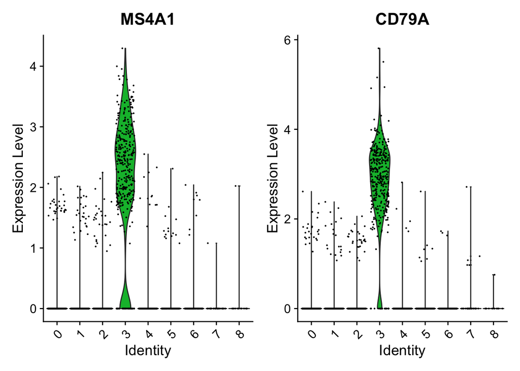

```r
VlnPlot(pbmc8, features = c("MS4A1", "CD79A"))
```

This violin plot shows expression probability distributions across clusters. It can be seen that the “MS4A1” and “CD79A” can be seen in cluster 3

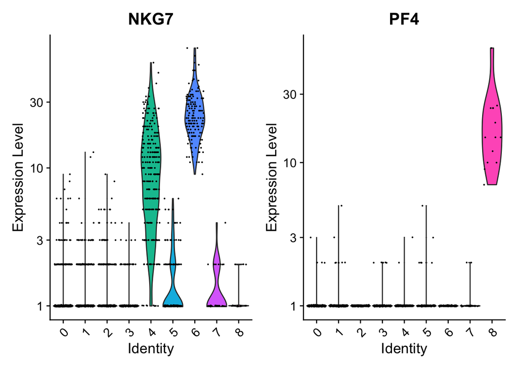

```r
# you can plot raw counts as well
VlnPlot(pbmc8, features = c("NKG7", "PF4"), slot = "counts", log = TRUE)
```

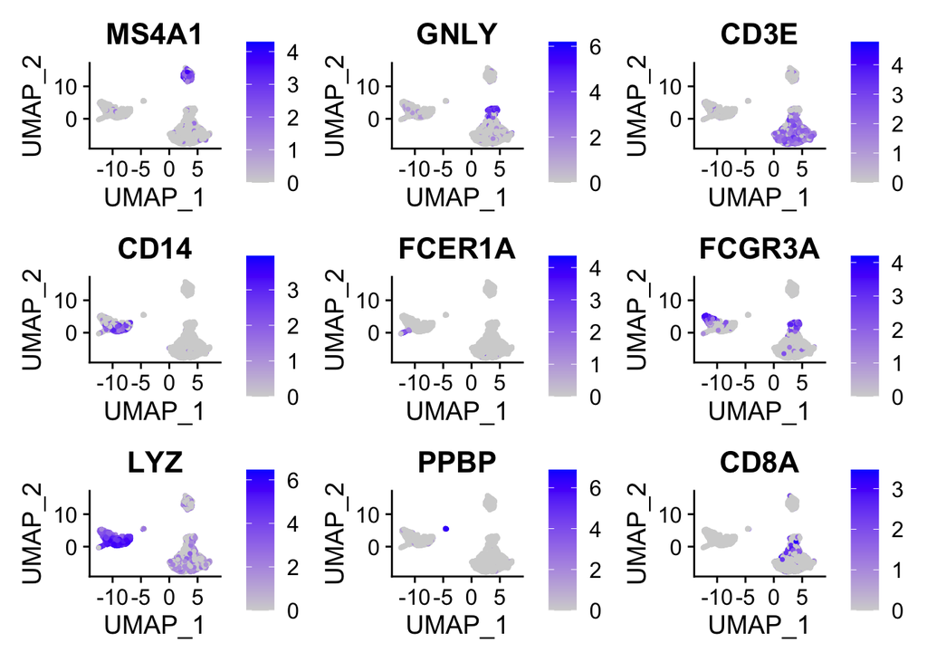

```r
FeaturePlot(pbmc8, features = c("MS4A1", "GNLY", "CD3E", "CD14", "FCER1A", "FCGR3A", "LYZ", "PPBP",
    "CD8A"))
```

This feature plots shows us the position of these biomarkers in different clusters

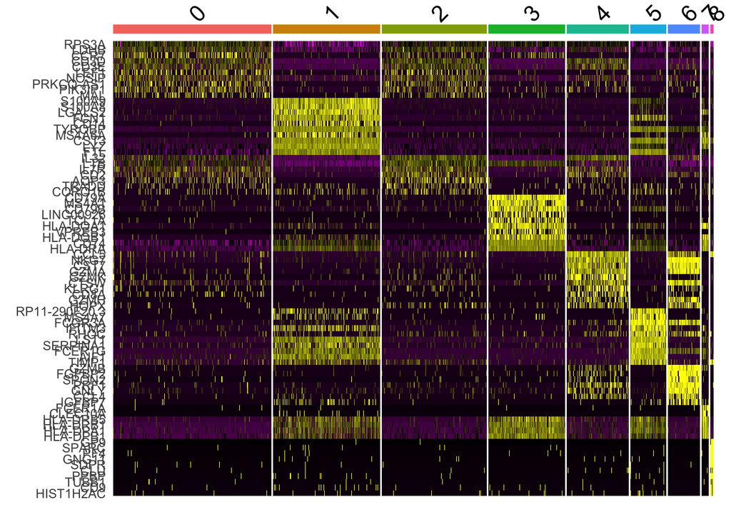

```r
pbmc.markers %>%
    group_by(cluster) %>%
    top_n(n = 10, wt = avg_log2FC) -> top10
DoHeatmap(pbmc8, features = top10$gene) + NoLegend()
```

**Assigning cell type identity to clusters** This tutorial has used the canonical markers to easily match the unbiased clustering to known cell types

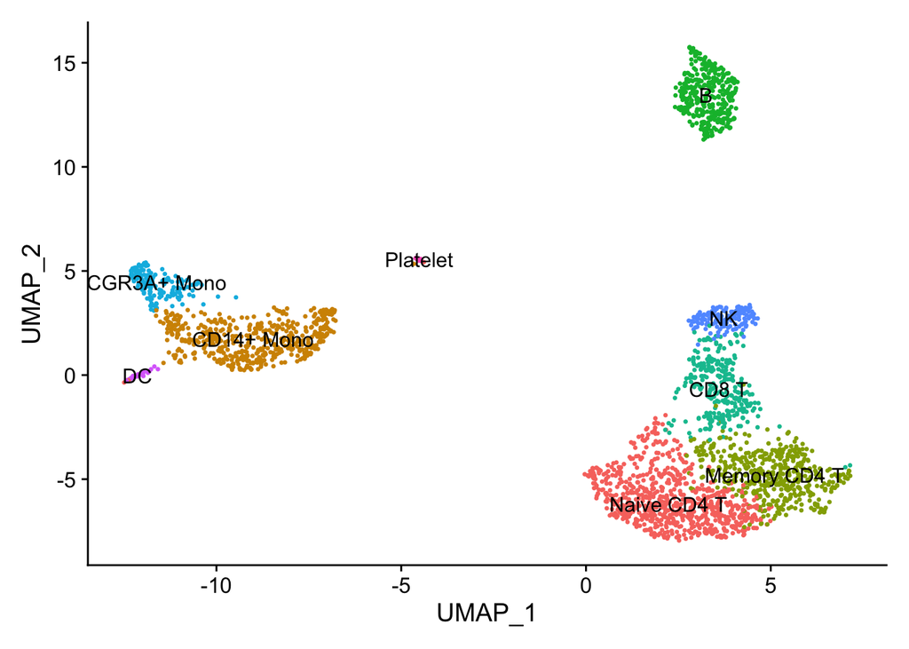

```r
# Giving the cell type identities to the clusters
new.cluster.ids <- c("Naive CD4 T", "CD14+ Mono", "Memory CD4 T", "B", "CD8 T", "FCGR3A+ Mono",
    "NK", "DC", "Platelet")
names(new.cluster.ids) <- levels(pbmc8)
pbmc9 <- RenameIdents(pbmc8, new.cluster.ids)
DimPlot(pbmc9, reduction = "umap", label = TRUE, pt.size = 0.5) + NoLegend()
```

It can be seen that the cells of cluster 0 are “Naive CD4 T” cells. Cells from cluster 1 are “CD14+ Mono” Cells from cluster 2 are “Memory CD4 T” Cells from cluster 3 are “B” Cells from cluster 4 are “CD8 T” Cells from cluster 5 are “FCGR3A+ Mono” Cells from cluster 6 are “NK” Cells from cluster 7 are “DC” Cells from cluster 8 are “Platelet”

Saving the file into the RDS format to contain the final results

```r
saveRDS(pbmc9, file = "pbmc3k_final.rds")
```